# Clase 17 de Septiembre

Javier Mauricio Sierra

## Introducción

La desigualdad económica es una de las problemáticas más persistentes a nivel mundial. A pesar del crecimiento económico global, los países continúan mostrando grandes diferencias en sus niveles de desarrollo y bienestar. Este análisis busca examinar algunos indicadores macroeconómicos claves como el Producto Interno Bruto (PIB) per cápita, la tasa de desempleo, la inflación y la deuda pública— con el fin de comprender mejor las diferencias y relaciones existentes entre ellos.

### Objetivos

**General:**  
Analizar la desigualdad económica entre distintos países a partir de indicadores como el PIB, la tasa de desempleo, la inflación y la deuda pública, con el fin de identificar patrones, diferencias regionales y posibles factores asociados.

Aplicar lo visto en clase analizando la desigualdad económica entre distintos países a partir de indicadores como el PIB, la tasa de desempleo, la inflación y la deuda pública, con el fin de identificar patrones, diferencias regionales y posibles factores asociados.

**Específicos:**  
1. Comparar el nivel de PIB per cápita entre los países para identificar diferencias significativas en el nivel de desarrollo económico.  
2. Examinar la relación entre la tasa de desempleo y el PIB para evaluar cómo el crecimiento económico influye en el empleo.  
3. Analizar la variabilidad de la inflación entre los países y su posible impacto en el poder adquisitivo y la estabilidad económica.

# 📊 Análisis Económico: PIB, Desempleo e Inflación

## 1. Nivel de PIB per cápita entre países

### 🧩 Descripción del análisis

```r
pib_region <- data %>%
  group_by(region) %>%
  summarize(mean_gdp = mean(GDP, na.rm = TRUE))

#
datatable(pib_region)
```

|  | region | mean_gdp |
| --- | --- | --- |
| 1 | Africa | 54.98 |
| 2 | Americas | 1324.413793103448 |
| 3 | Asia | 838.6041666666666 |
| 4 | Europe | 654.0975609756098 |
| 5 | Oceania | 412.2 |

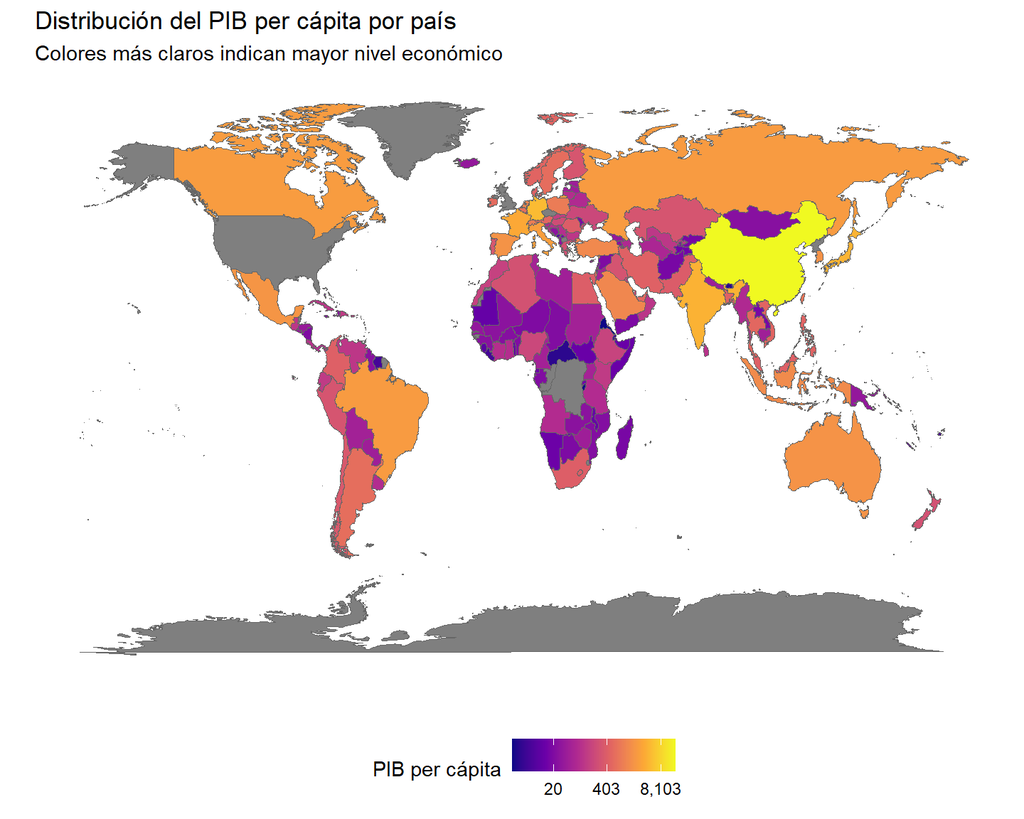

```r
world_map <- map_data("world")


continent_gdp <- data %>%
  group_by(region) %>%
  summarise(GDP_mean = mean(GDP, na.rm = TRUE))

map_data_joined <- world_map %>%
  left_join(data, by = c("region" = "name"))


ggplot(map_data_joined, aes(map_id = region, fill = GDP)) +
  geom_map(map = world_map, color = "gray40", size = 0.2) +
  expand_limits(x = world_map$long, y = world_map$lat) +
  scale_fill_viridis_c(option = "C", name = "PIB per cápita",
                       trans = "log", labels = scales::comma) +
  labs(
    title = "Distribución del PIB per cápita por país",
    subtitle = "Colores más claros indican mayor nivel económico",
    x = "", y = ""
  ) +
  theme_minimal() +
  theme(
    legend.position = "bottom",
    panel.grid = element_blank(),
    axis.text = element_blank()
  )
```

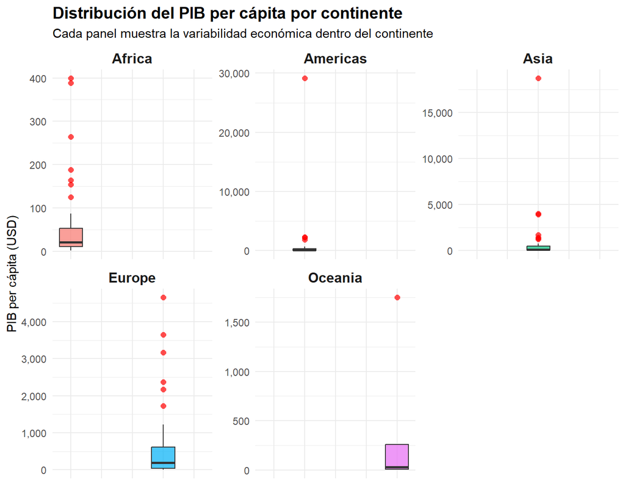

```r
data <- read.csv("base_de_datos.csv")
ggplot(data, aes(x = region, y = GDP, fill = region)) +
  geom_boxplot(outlier.colour = "red", outlier.shape = 16, outlier.size = 2, alpha = 0.7) +
  facet_wrap(~ region, scales = "free_y") +
  scale_y_continuous(labels = scales::comma) +
  labs(
    title = "Distribución del PIB per cápita por continente",
    subtitle = "Cada panel muestra la variabilidad económica dentro del continente",
    x = "",
    y = "PIB per cápita (USD)"
  ) +
  theme_minimal() +
  theme(
    legend.position = "none",
    strip.text = element_text(face = "bold", size = 12),
    plot.title = element_text(face = "bold", size = 14),
    axis.text.x = element_blank(),
    axis.ticks.x = element_blank()
  )
```

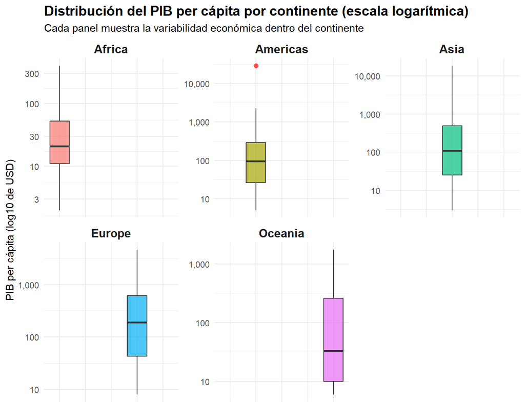

```r
data <- read.csv("base_de_datos.csv")


 ggplot(data, aes(x = region, y = GDP, fill = region)) +
  geom_boxplot(outlier.colour = "red", outlier.shape = 16, outlier.size = 2, alpha = 0.7) +
  facet_wrap(~ region, scales = "free_y") +
  scale_y_log10(labels = scales::comma) +
  labs(
    title = "Distribución del PIB per cápita por continente (escala logarítmica)",
    subtitle = "Cada panel muestra la variabilidad económica dentro del continente",
    x = "",
    y = "PIB per cápita (log10 de USD)"
  ) +
  theme_minimal() +
  theme(
    legend.position = "none",
    strip.text = element_text(face = "bold", size = 12),
    plot.title = element_text(face = "bold", size = 14),
    axis.text.x = element_blank(),
    axis.ticks.x = element_blank()
  )
```